# Funções úteis para organizar dados da COVID-19

Neste tutorial, escrito por Adriano Belisário para a Escola de Dados, veremos algumas funções úteis para trabalhar com dados da COVID-19 na prática, a partir do repositório da [Johns Hopkins University](https://github.com/CSSEGISandData/COVID-19).

Os códigos estão comentados, de modo a facilitar a compreensão para leigos, porém, no geral vamos assumir conhecimento básico de R. Também utlizaremos o pacote `tidyverse`.

**Atenção:** Tenha cuidado redobrado ao compartilhar conclusões, visualizações e análises sobre dados de saúde pública, especialmente em meio a uma pandemia mundial. O intuito deste tutorial é apenas facilitar o acesso aos dados sobre o novo coronavírus, em especial para jornalistas. Porém, recomendamos uma consulta a especialistas da área, caso você queira utilizar algum achado em uma publicação.

```r
library(tidyverse)
```

# Importando os dados

O primeiro passo é baixar os dados e entender a sua estrutura.

```r
# Vamos chamar o link com o CSV de "url"
url = 'https://raw.githubusercontent.com/CSSEGISandData/COVID-19/master/csse_covid_19_data/csse_covid_19_time_series/time_series_covid19_confirmed_global.csv'
# Agora, importamos o CSV no R...
dados = read.csv(url)
#... e o visualizamos
dados
```

| Province.State | Country.Region | Lat | Long | X1.22.20 | X1.23.20 | X1.24.20 | X1.25.20 | X1.26.20 | X1.27.20 | X1.28.20 | X1.29.20 | X1.30.20 | X1.31.20 | X2.1.20 | X2.2.20 | X2.3.20 | X2.4.20 | X2.5.20 | X2.6.20 | X2.7.20 | X2.8.20 | X2.9.20 | X2.10.20 | X2.11.20 | X2.12.20 | X2.13.20 | X2.14.20 | X2.15.20 | X2.16.20 | … |
| --- | --- | --- | --- | --- | --- | --- | --- | --- | --- | --- | --- | --- | --- | --- | --- | --- | --- | --- | --- | --- | --- | --- | --- | --- | --- | --- | --- | --- | --- | --- |
|  | Afghanistan | 33.000000 | 65.000000 | 0 | 0 | 0 | 0 | 0 | 0 | 0 | 0 | 0 | 0 | 0 | 0 | 0 | 0 | 0 | 0 | 0 | 0 | 0 | 0 | 0 | 0 | 0 | 0 | 0 | 0 | … |
|  | Albania | 41.153300 | 20.168300 | 0 | 0 | 0 | 0 | 0 | 0 | 0 | 0 | 0 | 0 | 0 | 0 | 0 | 0 | 0 | 0 | 0 | 0 | 0 | 0 | 0 | 0 | 0 | 0 | 0 | 0 | … |
|  | Algeria | 28.033900 | 1.659600 | 0 | 0 | 0 | 0 | 0 | 0 | 0 | 0 | 0 | 0 | 0 | 0 | 0 | 0 | 0 | 0 | 0 | 0 | 0 | 0 | 0 | 0 | 0 | 0 | 0 | 0 | … |
|  | Andorra | 42.506300 | 1.521800 | 0 | 0 | 0 | 0 | 0 | 0 | 0 | 0 | 0 | 0 | 0 | 0 | 0 | 0 | 0 | 0 | 0 | 0 | 0 | 0 | 0 | 0 | 0 | 0 | 0 | 0 | … |
|  | Angola | -11.202700 | 17.873900 | 0 | 0 | 0 | 0 | 0 | 0 | 0 | 0 | 0 | 0 | 0 | 0 | 0 | 0 | 0 | 0 | 0 | 0 | 0 | 0 | 0 | 0 | 0 | 0 | 0 | 0 | … |
|  | Antigua and Barbuda | 17.060800 | -61.796400 | 0 | 0 | 0 | 0 | 0 | 0 | 0 | 0 | 0 | 0 | 0 | 0 | 0 | 0 | 0 | 0 | 0 | 0 | 0 | 0 | 0 | 0 | 0 | 0 | 0 | 0 | … |
|  | Argentina | -38.416100 | -63.616700 | 0 | 0 | 0 | 0 | 0 | 0 | 0 | 0 | 0 | 0 | 0 | 0 | 0 | 0 | 0 | 0 | 0 | 0 | 0 | 0 | 0 | 0 | 0 | 0 | 0 | 0 | … |
|  | Armenia | 40.069100 | 45.038200 | 0 | 0 | 0 | 0 | 0 | 0 | 0 | 0 | 0 | 0 | 0 | 0 | 0 | 0 | 0 | 0 | 0 | 0 | 0 | 0 | 0 | 0 | 0 | 0 | 0 | 0 | … |
| Australian Capital Territory | Australia | -35.473500 | 149.012400 | 0 | 0 | 0 | 0 | 0 | 0 | 0 | 0 | 0 | 0 | 0 | 0 | 0 | 0 | 0 | 0 | 0 | 0 | 0 | 0 | 0 | 0 | 0 | 0 | 0 | 0 | … |
| New South Wales | Australia | -33.868800 | 151.209300 | 0 | 0 | 0 | 0 | 3 | 4 | 4 | 4 | 4 | 4 | 4 | 4 | 4 | 4 | 4 | 4 | 4 | 4 | 4 | 4 | 4 | 4 | 4 | 4 | 4 | 4 | … |

[output cut: 248 more lines]

Você pode navegar pela tabela utilizando a páginação acima. Podemos ver que temos os seguintes campos:

- **Province.State** (província, por exemplo, Guiana Francesa)
- **Country.Region** (país, por exemplo, França)
- **Lat** (latitude)
- **Long** (longitude)
- **Datas**: e na sequência temos várias datas, registrando a série histórica de cada país. Cada dia é uma coluna.

# Filtrando dados

Filtrar os registros é bem fácil. Abaixo, vamos criar um novo conjunto de dados (`df`) filtrando apenas os registros com Espanha e Itália no campo `Country.Region`.

Depois, vamos excluir as colunas `Province.State`, `Lat` e `Long`, que não nos interessam.

Repare que podemos selecionar as colunas que não queremos com o sinal de negativo (`-`) com o comando select. Usaremos esse recurso novamente no comando seguinte. E também que a barra em pé (`|`) significa o operador “OU”.

```r
df <- dados %>% filter(Country.Region == 'Italy' | Country.Region == 'Spain') %>%
  select(-Province.State,-Lat,-Long)
df
```

| Country.Region | X1.22.20 | X1.23.20 | X1.24.20 | X1.25.20 | X1.26.20 | X1.27.20 | X1.28.20 | X1.29.20 | X1.30.20 | X1.31.20 | X2.1.20 | X2.2.20 | X2.3.20 | X2.4.20 | X2.5.20 | X2.6.20 | X2.7.20 | X2.8.20 | X2.9.20 | X2.10.20 | X2.11.20 | X2.12.20 | X2.13.20 | X2.14.20 | X2.15.20 | X2.16.20 | X2.17.20 | X2.18.20 | X2.19.20 | … |
| --- | --- | --- | --- | --- | --- | --- | --- | --- | --- | --- | --- | --- | --- | --- | --- | --- | --- | --- | --- | --- | --- | --- | --- | --- | --- | --- | --- | --- | --- | --- |
| Italy | 0 | 0 | 0 | 0 | 0 | 0 | 0 | 0 | 0 | 2 | 2 | 2 | 2 | 2 | 2 | 2 | 3 | 3 | 3 | 3 | 3 | 3 | 3 | 3 | 3 | 3 | 3 | 3 | 3 | … |
| Spain | 0 | 0 | 0 | 0 | 0 | 0 | 0 | 0 | 0 | 0 | 1 | 1 | 1 | 1 | 1 | 1 | 1 | 1 | 2 | 2 | 2 | 2 | 2 | 2 | 2 | 2 | 2 | 2 | 2 | … |

# Transformando colunas em linhas

Para facilitar a análise e visualização dos dados, ao invés de ter várias colunas, vamos criar uma variável (ou uma nova coluna) que contenha o dia e outra que tenha o número de casos. Assim, podemos resumir aquelas várias colunas em apenas duas.

Você pode utilizar diversas funções, como a `gather` ou a `pivot_longer`. Para nosso exemplo, ambas são muitos semelhantes, mas a primeira será descontinuada pela equipe de desenvolvedores, então, recomendamos utilizar a `pivot_longer`.

Basicamente, precisamos definir três parâmetros para elas realizarem seu trabalho:

- Dados: Quais as colunas serão alvos da transformação? No nosso caso, as que possuem a contagem de casos por dia, ou seja, todas menos a do país.
- Chave: Como será chamada a variável que guardará o nome das colunas? No nosso caso, “dia”.
- Valores: Como será chamada a variável que guardará os valores das células? Vamos nomeá-la de “casos”

Veja abaixo como utilizamos estes parâmetros em ambas as funções.

```r
# Se você não conseguir rodar a função abaixo, talvez precise atualizar o pacote "tidyr"
# Neste caso, voocê pode rodar o comando install.packages("tidyr")
# Ou utilizar a função gather
# df <- df %>% gather(dia,casos,-Country.Region)
df <- df %>% pivot_longer(-Country.Region,"dia",values_to = "casos")
df
```

| Country.Region | dia | casos |
| --- | --- | --- |
| Italy | X1.22.20 | 0 |
| Italy | X1.23.20 | 0 |
| Italy | X1.24.20 | 0 |
| Italy | X1.25.20 | 0 |
| Italy | X1.26.20 | 0 |
| Italy | X1.27.20 | 0 |
| Italy | X1.28.20 | 0 |
| Italy | X1.29.20 | 0 |
| Italy | X1.30.20 | 0 |
| Italy | X1.31.20 | 2 |

[output cut: 136 more lines]

# Transformando textos em datas

Legal! Agora, precisamos definir que o campo “dia” deve ser encarado como uma data. Repare bem no padrão da data na tabela acima.

Ela é uma sequência de caraceteres (indicado pela sigla “chr” no cabeçalho). A primeira coisa que faremos é tirar este “X” e depois formatar a coluna como data.

Primeiro, vamos usar uma função para substituir (replace) uma sequência de caracteres (string ou str), a função str_replace. Com ela, vamos trocar no campo “dia” do banco de dados “df” qualquer ocorrência de X por uma sequência vazia, Ou seja, na prática, removeremos todos os “X”.

Depois, vamos mudar o campo para o formato de data com a função `as.Data`. O ponto logo após o parantêses é o primeiro parâmetro e significa que pegaremos o resultado da operação anterior, ou seja, os números das datas sem o X. Depois, explicitamos o formato data que é mês (%m), dia (%d) e ano (%y) - separados por um ponto.

```r
df$dia <- str_replace(df$dia,"X", "") %>%
  as.Date(.,format='%m.%d.%y')
# Vamos checar se funcionou vendo o dia mais recente, já no formato correto
max(df$dia)
```

```
[1] "2020-04-03"
```

Agora, conseguimos visualizar os registros ordenados por data. Repare na tabela abaixo que agora o dia aparece como “date” o/

```r
df %>% arrange(dia)
```

| Country.Region | dia | casos |
| --- | --- | --- |
| Italy | 2020-01-22 | 0 |
| Spain | 2020-01-22 | 0 |
| Italy | 2020-01-23 | 0 |
| Spain | 2020-01-23 | 0 |
| Italy | 2020-01-24 | 0 |
| Spain | 2020-01-24 | 0 |
| Italy | 2020-01-25 | 0 |
| Spain | 2020-01-25 | 0 |
| Italy | 2020-01-26 | 0 |
| Spain | 2020-01-26 | 0 |

[output cut: 136 more lines]

# Identificando o dia zero

Uma métrica bastante comum em análise de epidemias é a contagem de quantos dias se passaram desde determinado limar de casos. Isso facilita a comparação de fenômenos que ocorreram em datas distintas.

Abaixo, vamos adicionar uma nova coluna que conte quantos dias se passaram desde o centésimo caso nos dois países. O primeiro dia que a Itália registrou mais que 100 casos foi dia 23 de fevereiro, enquanto na Espanha foi apenas no dia 2 de março.

```r
df <- df %>%
  # A ordem das datas é fundamental, então, vamos ordenar os dados por dia
  arrange(dia) %>%
  # E filtra os registros menores que 100. Você pode trocar por qualquer outro valor.
  # Troque por 0 para pegar todos os dias desde o primeiro caso.
  filter(casos > 100)  %>%
  # Então, vamos usar o group_by para que a operação a seguir seja feita para cada país (Country.Region)
  group_by(Country.Region) %>%
  # Vamos definir o dia 0 como o menor dia daquele país
  mutate(dia0 = min(dia))
df
```

| Country.Region | dia | casos | dia0 |
| --- | --- | --- | --- |
| Italy | 2020-02-23 | 155 | 2020-02-23 |
| Italy | 2020-02-24 | 229 | 2020-02-23 |
| Italy | 2020-02-25 | 322 | 2020-02-23 |
| Italy | 2020-02-26 | 453 | 2020-02-23 |
| Italy | 2020-02-27 | 655 | 2020-02-23 |
| Italy | 2020-02-28 | 888 | 2020-02-23 |
| Italy | 2020-02-29 | 1128 | 2020-02-23 |
| Italy | 2020-03-01 | 1694 | 2020-02-23 |
| Italy | 2020-03-02 | 2036 | 2020-02-23 |
| Spain | 2020-03-02 | 120 | 2020-03-02 |

[output cut: 64 more lines]

# Contagem de dias

Já sabemos a data de registro e a data do primeiro caso, para cada registro de nossa tabela. Agora, está fácil calcularmos a diferença entre os dias. Assim, podemos analisar como cada país estava uma semana após a passar o limiar do centésimo caso, por exemplo.

Vamos criar uma nova variável (conta_dia) que vai ser o resultado da diferença entre a data de registro (dia) e o dia 0 (dia0) em dias.

```r
# Vamos adicionar o novo campo
df$conta_dia <- difftime(df$dia,df$dia0,units = "days")
# E visualizar os dados ordernados por ele
df %>% arrange(conta_dia)
```

| Country.Region | dia | casos | dia0 | conta_dia |
| --- | --- | --- | --- | --- |
| Italy | 2020-02-23 | 155 | 2020-02-23 | 0 days |
| Spain | 2020-03-02 | 120 | 2020-03-02 | 0 days |
| Italy | 2020-02-24 | 229 | 2020-02-23 | 1 days |
| Spain | 2020-03-03 | 165 | 2020-03-02 | 1 days |
| Italy | 2020-02-25 | 322 | 2020-02-23 | 2 days |
| Spain | 2020-03-04 | 222 | 2020-03-02 | 2 days |
| Italy | 2020-02-26 | 453 | 2020-02-23 | 3 days |
| Spain | 2020-03-05 | 259 | 2020-03-02 | 3 days |
| Italy | 2020-02-27 | 655 | 2020-02-23 | 4 days |
| Spain | 2020-03-06 | 400 | 2020-03-02 | 4 days |

[output cut: 64 more lines]

# Calculando o número de casos novos por dia

Repare que a coluna “casos” traz o total de casos acumulado até a data especificada no campo “dia”. Mas e se quisermos saber o número de novos casos por dia?

Vamos criar uma nova coluna chamada `novos_casos`, que será resultado do número de casos do dia menos o número de casos do dia anterior, em cada país.

```r
df <- df %>%
  # Vamos remover a coluna day0 pois ela não é mais necessária
  select(-dia0) %>%
  # Agrupamos por país
  group_by(Country.Region) %>%
  # Lembrando que nossos casos já estão ordenados por dia
  # Então, utilizamos a função lag() para retornar o último valor daquela coluna
  mutate(novos_casos = casos - lag(casos))
df
```

| Country.Region | dia | casos | conta_dia | novos_casos |
| --- | --- | --- | --- | --- |
| Italy | 2020-02-23 | 155 | 0 days | NA |
| Italy | 2020-02-24 | 229 | 1 days | 74 |
| Italy | 2020-02-25 | 322 | 2 days | 93 |
| Italy | 2020-02-26 | 453 | 3 days | 131 |
| Italy | 2020-02-27 | 655 | 4 days | 202 |
| Italy | 2020-02-28 | 888 | 5 days | 233 |
| Italy | 2020-02-29 | 1128 | 6 days | 240 |
| Italy | 2020-03-01 | 1694 | 7 days | 566 |
| Italy | 2020-03-02 | 2036 | 8 days | 342 |
| Spain | 2020-03-02 | 120 | 0 days | NA |

[output cut: 64 more lines]

# Calculando o aumento percentual

Vamos incrementar ainda mais. Agora vamos adicionar um novo campo que vai mostrar o aumento percentual no número acumulado de casos confirmados em cada dia.

Para relembrar, para calculá-la, pegamos o número de casos de um dia (`casos`), dividimos pelo total dia anterior (`lag(casos)`), diminuimos por 1 e então multiplicamos por 100 para obter a taxa percentual. E também vamos arredondar o resultado, usando a função `round()`.

```r
df <- df %>% mutate(aumento_percent = round((novos_casos/lag(casos)*100)))
df
```

| Country.Region | dia | casos | conta_dia | novos_casos | aumento_percent |
| --- | --- | --- | --- | --- | --- |
| Italy | 2020-02-23 | 155 | 0 days | NA | NA |
| Italy | 2020-02-24 | 229 | 1 days | 74 | 48 |
| Italy | 2020-02-25 | 322 | 2 days | 93 | 41 |
| Italy | 2020-02-26 | 453 | 3 days | 131 | 41 |
| Italy | 2020-02-27 | 655 | 4 days | 202 | 45 |
| Italy | 2020-02-28 | 888 | 5 days | 233 | 36 |
| Italy | 2020-02-29 | 1128 | 6 days | 240 | 27 |
| Italy | 2020-03-01 | 1694 | 7 days | 566 | 50 |
| Italy | 2020-03-02 | 2036 | 8 days | 342 | 20 |
| Spain | 2020-03-02 | 120 | 0 days | NA | NA |

[output cut: 64 more lines]

# Casos por milhão de habitantes

Ainda que seja amplamente utilizada por órgãos oficias e pela imprensa, alguns especialistas desencorajam o uso de taxas populacionais para avaliação da taxa de contágio nos estágios iniciais de uma pandemia. Isto pois o número de pessoas contagiadas por cada infectada não é alterada pelo tamanho da população, porém, à medida que a epidemia progride este número passa a ser útil. A taxa também pode ser um bom indicador se queremos avaliar o impacto na infra-estrutura de saúde, por exemplo, então, vamos ver como realizá-la. Para se aprofundar mais nesta discussão, vide o [item 4.4.2 deste artigo](https://github.com/paulohubert/covid_discussao/blob/master/comparando_paises_covid.pdf) ou esta matéria do [The New York Times](https://www.nytimes.com/interactive/2020/03/27/upshot/coronavirus-new-york-comparison.html).

Aqui, vamos adicionar uma coluna com a população dos países. Como este é apenas um exemplo e temos só 2 casos, podemos usar uma condicional simples. Se o país for a Itália, inserimos a população de 60 milhões (60483538), se não, então, será a Espanha, que tem população de 46 milhões (46750337).

```r
#
df <- df %>% mutate(populacao = ifelse(Country.Region == "Italy",60483538,46750337)) %>%
  # Uma vez que você insira a coluna de população, o cálculo da taxa é simples
mutate(taxa = round((casos/populacao) * 1000000))
df
```

| Country.Region | dia | casos | conta_dia | novos_casos | aumento_percent | populacao | taxa |
| --- | --- | --- | --- | --- | --- | --- | --- |
| Italy | 2020-02-23 | 155 | 0 days | NA | NA | 60483538 | 3 |
| Italy | 2020-02-24 | 229 | 1 days | 74 | 48 | 60483538 | 4 |
| Italy | 2020-02-25 | 322 | 2 days | 93 | 41 | 60483538 | 5 |
| Italy | 2020-02-26 | 453 | 3 days | 131 | 41 | 60483538 | 7 |
| Italy | 2020-02-27 | 655 | 4 days | 202 | 45 | 60483538 | 11 |
| Italy | 2020-02-28 | 888 | 5 days | 233 | 36 | 60483538 | 15 |
| Italy | 2020-02-29 | 1128 | 6 days | 240 | 27 | 60483538 | 19 |
| Italy | 2020-03-01 | 1694 | 7 days | 566 | 50 | 60483538 | 28 |
| Italy | 2020-03-02 | 2036 | 8 days | 342 | 20 | 60483538 | 34 |
| Spain | 2020-03-02 | 120 | 0 days | NA | NA | 46750337 | 3 |

[output cut: 64 more lines]

# Bônus: plotando o resultado em gráfico

Este não é um tutorial de visualização de dados, mas depois de chegar aqui nós merecemos ver o resultado do trabalho em um gráfico. Então, vamos lá!

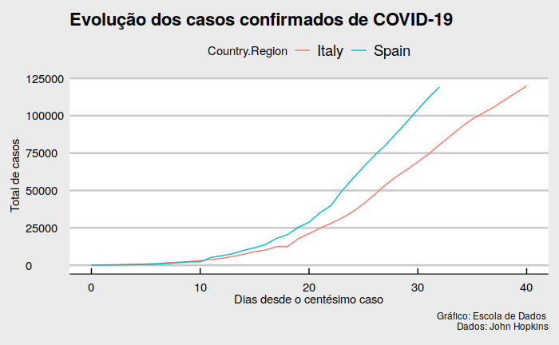

```r
# Vamos usar o tema da The Economist para deixar o gráfico bonito :)
library(ggthemes)
grafico <- ggplot(df, aes(x=conta_dia,y=casos, group = Country.Region, colour = Country.Region)) +
  geom_line() +
  theme_economist_white() +
  labs(caption = "Gráfico: Escola de Dados \n Dados: John Hopkins") +
    labs(x = "Dias desde o centésimo caso", y = "Total de casos",
         title = "Evolução dos casos confirmados de COVID-19")
grafico
```

## Bônus extra: escala logarítimica

Repare como as duas escalas permitem análises diferentes.

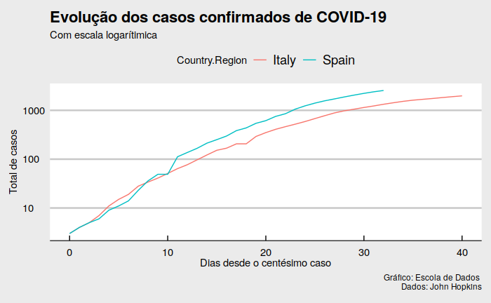

```r
grafico <- ggplot(df, aes(x=as.double(conta_dia),y=taxa, group = Country.Region, colour = Country.Region)) +
  geom_line() +
  theme_economist_white() +
  labs(caption = "Gráfico: Escola de Dados \n Dados: John Hopkins") +
    labs(x = "Dias desde o centésimo caso", y = "Total de casos",
         title = "Evolução dos casos confirmados de COVID-19",
         subtitle = "Com escala logarítimica") + scale_y_log10()
grafico
```